# Data Analysis 3 - Assignment 2

The aim of the project is to create a predictive model, which is able to price mid-size apartments hosting 2-6 guests in Milan. The model will be chosen from 3 (4) different models, using different prediction methods. The four models are created with OLS, Lasso, Random Forest and GBM

Examine data:

```python
data.shape
```

```
(24177, 75)
```

We seem to have many observations, but we have to also check the quality of these.

```python
data.columns
```

```
Index(['id', 'listing_url', 'scrape_id', 'last_scraped', 'source', 'name',
       'description', 'neighborhood_overview', 'picture_url', 'host_id',
       'host_url', 'host_name', 'host_since', 'host_location', 'host_about',
       'host_response_time', 'host_response_rate', 'host_acceptance_rate',
       'host_is_superhost', 'host_thumbnail_url', 'host_picture_url',
       'host_neighbourhood', 'host_listings_count',
       'host_total_listings_count', 'host_verifications',
       'host_has_profile_pic', 'host_identity_verified', 'neighbourhood',
       'neighbourhood_cleansed', 'neighbourhood_group_cleansed', 'latitude',
       'longitude', 'property_type', 'room_type', 'accommodates', 'bathrooms',
       'bathrooms_text', 'bedrooms', 'beds', 'amenities', 'price',
       'minimum_nights', 'maximum_nights', 'minimum_minimum_nights',
       'maximum_minimum_nights', 'minimum_maximum_nights',
       'maximum_maximum_nights', 'minimum_nights_avg_ntm',
       'maximum_nights_avg_ntm', 'calendar_updated', 'has_availability',
       'availability_30', 'availability_60', 'availability_90',
       'availability_365', 'calendar_last_scraped', 'number_of_reviews',
       'number_of_reviews_ltm', 'number_of_reviews_l30d', 'first_review',
       'last_review', 'review_scores_rating', 'review_scores_accuracy',
       'review_scores_cleanliness', 'review_scores_checkin',
       'review_scores_communication', 'review_scores_location',
       'review_scores_value', 'license', 'instant_bookable',
       'calculated_host_listings_count',
       'calculated_host_listings_count_entire_homes',
       'calculated_host_listings_count_private_rooms',
       'calculated_host_listings_count_shared_rooms', 'reviews_per_month'],
      dtype='object')
```

```python
data.info()
```

```
<class 'pandas.core.frame.DataFrame'>
RangeIndex: 24177 entries, 0 to 24176
Data columns (total 75 columns):
 #   Column                                        Non-Null Count  Dtype
---  ------                                        --------------  -----
 0   id                                            24177 non-null  int64
 1   listing_url                                   24177 non-null  object
 2   scrape_id                                     24177 non-null  int64
 3   last_scraped                                  24177 non-null  object
 4   source                                        24177 non-null  object
 5   name                                          24177 non-null  object
 6   description                                   23761 non-null  object
 7   neighborhood_overview                         13101 non-null  object
 8   picture_url                                   24177 non-null  object
 9   host_id                                       24177 non-null  int64
```

[output cut: 67 more lines]

Checking NaN values

```python
# where do we have missing variables now?
to_filter=data.isna().sum()
to_filter[to_filter>0].index

# Filter the DataFrame to include only columns with missing values
filtered_data = data[to_filter[to_filter > 0].index]

# Count the number of missing values in each column of the filtered DataFrame
empty_na_values = filtered_data.isna().sum()

# Print the count of missing values in each column
print(empty_na_values)
```

```
description                       416
neighborhood_overview           11076
host_location                    4170
host_about                      11558
host_response_time               6180
host_response_rate               6180
host_acceptance_rate             4322
host_is_superhost                 527
host_neighbourhood              12939
neighbourhood                   11076
neighbourhood_group_cleansed    24177
bathrooms                       24177
bathrooms_text                      8
bedrooms                         5430
beds                              289
calendar_updated                24177
first_review                     4781
last_review                      4781
review_scores_rating             4781
review_scores_accuracy           4932
review_scores_cleanliness        4934
review_scores_checkin            4934
review_scores_communication      4933
review_scores_location           4935
review_scores_value              4937
license                         18562
reviews_per_month                4781
dtype: int64
```

In some columns there is a huge number of na values, we have to deal with these later.

## Data Cleaning

Data cleaning and feature engineering is quite straitght forward, the biggest difficulty is the large number of possible variables. Here only the most impostant columns are presented and only the most complexŰ cleaning, the bathroom variable cleaning is shown:

```python
data["property_type"].value_counts()
```

```
Entire rental unit                    12985
Entire condo                           5009
Private room in rental unit            2484
Private room in condo                   973
Entire loft                             821
Entire home                             402
Entire serviced apartment               239
Private room in home                    176
Shared room in rental unit              169
Private room in bed and breakfast       164
Entire vacation home                    152
Private room in loft                     84
Room in hotel                            55
Room in boutique hotel                   48
Shared room in condo                     39
Private room in villa                    31
Shared room in hostel                    30
Tiny home                                25
Private room in vacation home            20
Entire townhouse                         19
Private room in serviced apartment       19
Private room in townhouse                19
Entire villa                             18
Entire place                             18
Private room in guest suite              18
Entire guest suite                       18
Private room in hostel                   17
Private room in casa particular          16
Room in bed and breakfast                12
Private room                             12
Shared room in home                      10
Shared room in loft                       9
Room in aparthotel                        9
Private room in tiny home                 7
Shared room in bed and breakfast          6
Room in hostel                            6
Casa particular                           5
Camper/RV                                 5
Private room in guesthouse                4
Entire guesthouse                         4
Private room in farm stay                 3
Entire home/apt                           3
Shared room in tiny home                  2
Room in serviced apartment                2
Entire chalet                             1
Island                                    1
Private room in nature lodge              1
Dome                                      1
Private room in cave                      1
Private room in camper/rv                 1
Boat                                      1
Barn                                      1
Private room in cottage                   1
Shared room in guesthouse                 1
Name: property_type, dtype: int64
```

```python
# Rename keep the most common property types - they are all apartments or rooms in apartments
data= data.loc[data.property_type.isin(["Entire rental unit", "Entire condo", "Private room in rental unit", "Private room in condo", "Entire loft",
                                        "Entire home", "Private room in home", "Shared room in rental unit"])]

data["f_property_type"] = data["property_type"].astype("category")
```

All the property types are similar, there are no houses in the most common categories, so wee keep only those

```python
data['room_type'].value_counts(dropna=False)
```

```
Entire home/apt    19217
Private room        3633
Shared room          169
Name: room_type, dtype: int64
```

```python
data["f_room_type"] = data["room_type"].astype("category")
data["f_room_type"] = (
    data["f_room_type"]
    .replace(
        {
            "Entire home/apt": "Entire/Apt",
            "Private room": "Private",
            "Shared room": "Shared",
        }
    )
    .astype("category")
)
```

```python
data["neighbourhood_cleansed"].value_counts(dropna=False)
```

```
BUENOS AIRES - VENEZIA    1793
DUOMO                     1148
SARPI                     1037
NAVIGLI                    987
LORETO                     978
                          ...
CHIARAVALLE                  4
PARCO AGRICOLO SUD           3
PARCO NORD                   2
QUINTOSOLE                   2
RONCHETTO DELLE RANE         1
Name: neighbourhood_cleansed, Length: 86, dtype: int64
```

It could mean an improvement to limit the neighbourhoods depending on the business case, but as there are no limitations to this so far all the neighbourhoods are kept

### Numerical columns:

```python
data['bathrooms_text'].value_counts()
```

```
1 bath               16948
2 baths               2134
1 shared bath         1786
1 private bath         851
1.5 baths              562
2 shared baths         190
3 baths                155
1.5 shared baths       128
2.5 baths              114
4 baths                 28
0 baths                 25
Half-bath               23
Shared half-bath        13
2.5 shared baths        12
3.5 baths               11
5 baths                 11
3 shared baths           7
0 shared baths           5
4.5 baths                2
6 baths                  2
Private half-bath        2
8 baths                  1
4 shared baths           1
7 baths                  1
10 baths                 1
Name: bathrooms_text, dtype: int64
```

As bathsrooms column is empty and this column is stored as text some cleaning is needed

```python
# convert bathrooms_text to float
# def function to clean the bathroom text, split and space and set to int, if not possible set to 1
def clean_bathroom(text):
    try:
        return float(text.split(" ")[0])
    except:
        return text == 0.5

# apply function to the column
data["bathrooms"] = data["bathrooms_text"].apply(clean_bathroom)
data.drop(columns="bathrooms_text", inplace=True)
```

An important change to the code used in class is the use of availabilty of accomodations. These variables show that out of the next 30, 60, 90, 365 days, how many are available for booking. An accomodation can be either unavailable because the host block out a timeframe for some alternative use to lending or because it's already booked. The assumption during this project is that this show the demand for the apartment and can be used as a predictor.

```python
data[["availability_30", "availability_60", "availability_90", "availability_365"]].describe()
```

|  | availability_30 | availability_60 | availability_90 | availability_365 |
| --- | --- | --- | --- | --- |
| count | 23019.000000 | 23019.000000 | 23019.000000 | 23019.000000 |
| mean | 9.158608 | 23.850732 | 41.205613 | 147.990616 |
| std | 9.889172 | 21.464930 | 33.610702 | 129.003487 |
| min | 0.000000 | 0.000000 | 0.000000 | 0.000000 |
| 25% | 0.000000 | 0.000000 | 0.000000 | 18.000000 |
| 50% | 6.000000 | 22.000000 | 46.000000 | 120.000000 |
| 75% | 17.000000 | 43.000000 | 73.000000 | 264.000000 |
| max | 30.000000 | 60.000000 | 90.000000 | 365.000000 |

```python
# renaming columns
for column in (
    "host_listings_count",
    "host_total_listings_count",
    "accommodates",
    "bathrooms",
    "bedrooms",
    "beds",
    "minimum_nights",
    "availability_30",
    "availability_60",
    "availability_90",
    "availability_365",
    "number_of_reviews",
    "number_of_reviews_ltm",
    "number_of_reviews_l30d",
    "review_scores_rating",
    "review_scores_accuracy",
    "review_scores_cleanliness",
    "review_scores_checkin",
    "review_scores_communication",
    "review_scores_location",
    "review_scores_value",
    "reviews_per_month",
):
    data["n_" + re.sub(r"[^[:alnum:]_]", "", column.lower())] = data[column].astype(
        "float"
    )
```

After examining all columns, these numerical columns columns seem to be usable so they are renamed and kept are renamed

Keeping all already renamed columns and some others

```python
data = pd.concat(
    [
        data[
            [
                "price",
                "id",
                "neighbourhood_cleansed",
                "room_type",
                "property_type",
                "amenities",
            ]
        ],
        data.filter(
            regex="^d_.*|^n_.*|^f_.*|^p_.*|^usd_.*|da_.*"
        ),
    ],
    axis=1,
)
```

To deal with amenities, dummies are created from the 50 most frequent ones:

```python
import ast

# Clean amenities column
data['new_amenities'] = data['amenities'].apply(lambda x: ast.literal_eval(x))

# Create a list of all amenities
all_amenities = []

for lst in data['new_amenities']:
    for amenity in lst:
        all_amenities.append(amenity)

# Create a series of the 50 most frequent amenities
top50_amenities = pd.Series(all_amenities).value_counts().head(50)

# Create a list of the top 50 amenities
amenities_list = top50_amenities.index.tolist()

# Create a variable for each top 100 amenity starting with "d_"
for my_amenities in amenities_list:
    data['da_' + my_amenities] = data['new_amenities'].apply(lambda x: 1 if my_amenities in x else 0)

# Rename columns, as amenities can have spaces and uppercase characters
data.columns = [name.replace(' ', '_').replace("–","").replace("-","").replace("’","").replace(":","").replace("/","_").lower() for name in data.columns]

# Drop the original amenities column
data = data.drop(columns=['amenities', 'new_amenities'])
```

```python
# where do we have missing variables now?
to_filter=data.isna().sum()
to_filter[to_filter>0].index
```

```
Index(['d_host_is_superhost', 'p_host_acceptance_rate', 'n_bedrooms', 'n_beds',
       'n_review_scores_rating', 'n_review_scores_accuracy',
       'n_review_scores_cleanliness', 'n_review_scores_checkin',
       'n_review_scores_communication', 'n_review_scores_location',
       'n_review_scores_value', 'n_reviews_per_month'],
      dtype='object')
```

To deal with empty values one of the following methd is used.

1. Accomodations which have no reviews scores are dropped.
2. Host response rate wont be used as a variable.
3. The other variables are flagged and then imputed as there is only a handful of them

```python
# Filter the DataFrame to include only columns with missing values
filtered_data = data[to_filter[to_filter > 0].index]

# Count the number of missing values in each column of the filtered DataFrame
empty_na_values = filtered_data.isna().sum()

# Print the count of missing values in each column
print(empty_na_values)
```

```
d_host_is_superhost               453
p_host_acceptance_rate           2328
n_bedrooms                       3890
n_beds                            195
n_review_scores_rating              0
n_review_scores_accuracy          144
n_review_scores_cleanliness       146
n_review_scores_checkin           146
n_review_scores_communication     145
n_review_scores_location          147
n_review_scores_value             149
n_reviews_per_month                 0
dtype: int64
```

```python
# first create flags for missing variables, then input with median.

data = data.assign(
    # flag for superhost
    flag_host_is_superhost=np.multiply(data.d_host_is_superhost.isna(), 1),
    d_host_is_superhost=data.d_host_is_superhost.fillna(np.median(data.d_host_is_superhost.dropna())),

    # flag for response rate
    #flag_host_response_rate=np.multiply(data.p_host_response_rate.isna(), 1),
    #p_host_response_rate=data.p_host_response_rate.fillna(np.median(data.p_host_response_rate.dropna())),

    # flag for acceptance rate
    flag_host_acceptance_rate=np.multiply(data.p_host_acceptance_rate.isna(), 1),
    p_host_acceptance_rate=data.p_host_acceptance_rate.fillna(np.median(data.p_host_acceptance_rate.dropna())),

    # flag for beds
    flag_beds=np.multiply(data.n_beds.isna(), 1),
    n_beds=data.n_beds.fillna(np.median(data.n_beds.dropna())),
    # flag for bedrooms
    flag_bedrooms=np.multiply(data.n_bedrooms.isna(), 1),
    n_bedrooms=data.n_bedrooms.fillna(np.median(data.n_bedrooms.dropna())),
    # flag for accuracy score
    flag_review_scores_rating=np.multiply(data.n_review_scores_accuracy.isna(), 1),
    n_review_scores_accuracy=data.n_review_scores_accuracy.fillna(
        np.median(data.n_review_scores_accuracy.dropna())),
    # flag for cleaniness reviews
    flag_review_scores_cleanliness=np.multiply(data.n_review_scores_cleanliness.isna(), 1),
    n_review_scores_cleanliness=data.n_review_scores_cleanliness.fillna(
        np.median(data.n_review_scores_cleanliness.dropna())),
    # flag for checkin reviews
    flag_review_scores_checkin=np.multiply(data.n_review_scores_checkin.isna(), 1),
    n_review_scores_checkin=data.n_review_scores_checkin.fillna(
        np.median(data.n_review_scores_checkin.dropna())),
    # flag for communication reviews
    flag_review_scores_communication=np.multiply(data.n_review_scores_communication.isna(), 1),
    n_review_scores_communication=data.n_review_scores_communication.fillna(
        np.median(data.n_review_scores_communication.dropna())),
    # flag for location reviews
    flag_review_scores_location=np.multiply(data.n_review_scores_location.isna(), 1),
    n_review_scores_location=data.n_review_scores_location.fillna(
        np.median(data.n_review_scores_location.dropna())),
    # flag for value reviews
    flag_review_scores_value=np.multiply(data.n_review_scores_value.isna(), 1),
    n_review_scores_value=data.n_review_scores_value.fillna(
        np.median(data.n_review_scores_value.dropna())),
)
```

Filtering is used to drop accomodations out of the prediction scope and with mistakes

```python
## drop accomodates > 6
data = data.loc[(data.n_accommodates <= 6) & (data.n_accommodates >= 2)]
```

```python
data["n_bathrooms"].describe(percentiles=[0.01, 0.25, 0.5, 0.75, 0.95])
```

```
count    17135.000000
mean         1.122031
std          0.350160
min          0.000000
1%           1.000000
25%          1.000000
50%          1.000000
75%          1.000000
95%          2.000000
max          6.000000
Name: n_bathrooms, dtype: float64
```

```python
## drop bathrooms >
data=data.loc[data.n_bathrooms < 3]
```

```python
data["n_beds"].describe(percentiles=[0.01, 0.25, 0.5, 0.75, 0.95])
```

```
count    17039.000000
mean         1.761840
std          0.912203
min          1.000000
1%           1.000000
25%          1.000000
50%          2.000000
75%          2.000000
95%          3.000000
max         14.000000
Name: n_beds, dtype: float64
```

```python
data["n_beds"].value_counts()
```

```
1.0     7843
2.0     6602
3.0     1745
4.0      630
5.0      133
6.0       73
7.0        4
8.0        4
9.0        2
13.0       1
14.0       1
10.0       1
Name: n_beds, dtype: int64
```

```python
## drop bathrooms >
data=data.loc[data.n_beds <= 8]
```

## EDA

```python
data=data.loc[data.price <400]
```

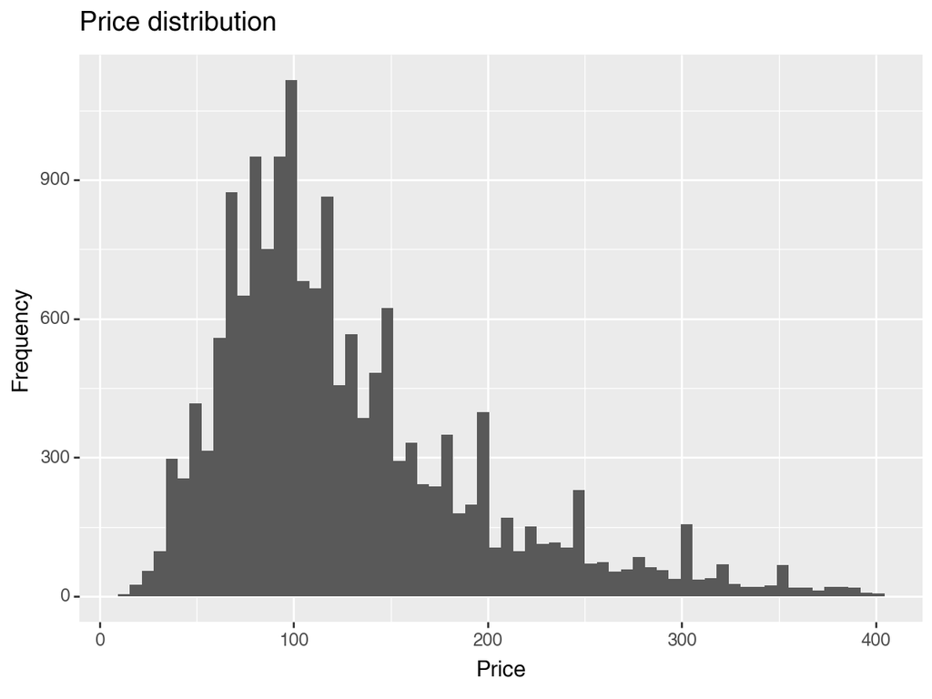

```
<Figure Size: (640 x 480)>
```

```python
(
    ggplot(data, aes("price"))
    + geom_histogram()
    + labs(title="Price distribution", x="Price", y="Frequency")
)
```

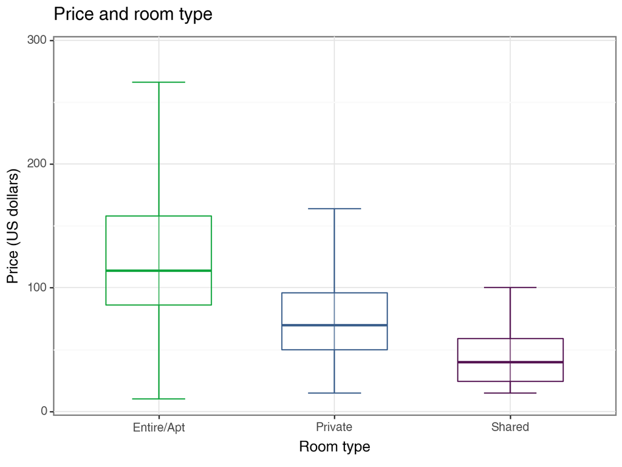

```
<Figure Size: (640 x 480)>
```

```python
## Boxplot of price by room type
(
    ggplot(data, aes(x="f_room_type", y="price"))
    + stat_boxplot(
        aes(group="f_room_type"),
        geom="errorbar",
        width=0.3,
        color=(color[1], color[0], color[2]),
        size=0.5,
        na_rm=True,
    )
    + geom_boxplot(
        aes(group="f_room_type"),
        color=(color[1], color[0], color[2]),
        # fill=(color[1], color[0], color[2]),
        size=0.5,
        width=0.6,
        alpha=0.3,
        na_rm=True,
        outlier_shape="",
    )
    + scale_y_continuous(expand=(0.01, 0.01), limits=(0, 300), breaks=seq(0, 301, 100))
    + labs(title="Price and room type", x="Room type", y="Price (US dollars)")
    + theme_bw()
)
```

```python
data.groupby(["n_beds"]).agg(mean_price=("price", np.mean))
```

| n_beds | mean_price |
| --- | --- |
| 1.0 | 115.751464 |
| 2.0 | 131.840634 |
| 3.0 | 156.756292 |
| 4.0 | 161.813264 |
| 5.0 | 174.059322 |
| 6.0 | 160.625000 |
| 7.0 | 282.250000 |
| 8.0 | 115.500000 |

We try to search for amenitiy dummies that interact with room_type. In this report one example is shown

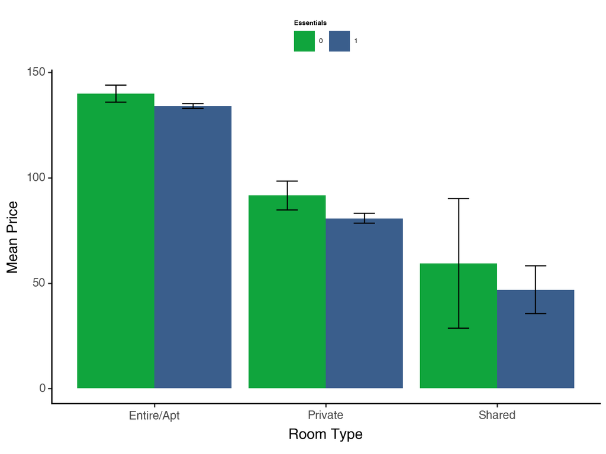

```
<Figure Size: (640 x 480)>
```

```python
price_diff_by_variables(
    data,
    "f_room_type",
    "da_essentials",
    "Room Type",
    "Essentials",
)
```

Kitchen and essentials show some potential

## OLS

For OLS we use non-linear variables as well:

```python
# Squares and further values to create
data = data.assign(
    n_accommodates2=lambda x: x["n_accommodates"] ** 2,
    ln_accommodates=lambda x: np.log(x["n_accommodates"]),
)
```

The following variables, and interactions are used:

```python
#####################
# Setting up models #
#####################
# Basic Variables
basic = (
    "f_room_type",
    "n_accommodates",
    "n_bedrooms",
    "n_beds",
    "flag_beds",
    "flag_bedrooms",
    "f_property_type",
    "f_neighbourhood_cleansed",
    "n_bathrooms",
    "n_minimum_nights",
)

host = ("d_host_is_superhost",
       "d_host_has_profile_pic",
       "d_host_identity_verified",
       "p_host_acceptance_rate"
)

availability = ("n_availability_30",
                "n_availability_60",
                "n_availability_90",
                "n_availability_365")



reviews = ("n_number_of_reviews", "n_review_scores_rating", "flag_review_scores_rating",
           "n_number_of_reviews_ltm", "n_number_of_reviews_l30d", "n_review_scores_accuracy",
            "n_review_scores_cleanliness", "n_review_scores_checkin", "n_review_scores_communication",
            "n_review_scores_location", "n_review_scores_value", "n_reviews_per_month",
            "flag_review_scores_cleanliness", "flag_review_scores_checkin",
            "flag_review_scores_communication", "flag_review_scores_location", "flag_review_scores_value"
)

poly_lev = ("n_accommodates2","ln_accommodates")


# not use p_host_response_rate due to missing obs
amenities = [col for col in data if col.startswith("da_")]
```

```python
X1 = "f_room_type:f_property_type"
X2 = (" + f_room_type:da_essentials", "f_room_type:da_kitchen")
X3 = "(f_property_type + n_accommodates + n_beds + n_bedrooms + f_room_type + n_bathrooms + n_availability_365 + n_number_of_reviews):(" + "+".join(amenities) + ")"


modellev1 = "~ n_accommodates"
modellev2 = "~" + "+".join(basic)
modellev3 = "~" + "+".join(basic) + "+" + "+".join(host)
modellev4 = "~" + "+".join(basic) + "+" + "+".join(host) + "+" + "+".join(availability)
modellev5 = "~" + "+".join(basic) + "+" + "+".join(host) + "+" + "+".join(availability)+ "+" + "+".join(reviews)+ "+" + "+" + X1
modellev6 = "~" + "+".join(basic) + "+" + "+".join(host) + "+" + "+".join(availability)+ "+" + "+".join(reviews)+ "+" + "+" + X1+"+"+"+".join(X2)
modellev7 = "~" + "+".join(basic) + "+" + "+".join(host) + "+" + "+".join(availability)+ "+" + "+".join(reviews)+ "+" + "+".join(poly_lev)+ "+" + "+" + X1+"+"+"+".join(X2)+ "+" + "+".join(amenities)
modellev8 = ("~"+ "+".join(basic)+ "+" + "+".join(host) + "+" + "+".join(availability)+ "+"+ "+".join(reviews)+ "+" + "+".join(poly_lev)+ "+"+ X1+ "+"+ "+".join(X2)+ "+"+ "+".join(amenities)+ "+"+ X3)
```

```python
data_work.shape
```

```
(13158, 97)
```

```python
data_holdout.shape
```

```
(3288, 97)
```

Both work and Hold-out sets have sufficient data

```python
summarize_cv(cv_list)
```

|  | Model1 | Model2 | Model3 | Model4 | Model5 | Model6 | Model7 | Model8 |
| --- | --- | --- | --- | --- | --- | --- | --- | --- |
| Fold1 | 64.740598 | 55.208355 | 55.045532 | 52.695357 | 51.903862 | 51.897964 | 50.614128 | 48.442608 |
| Fold2 | 64.042397 | 55.049763 | 54.899516 | 52.170291 | 51.137512 | 51.126913 | 49.985931 | 47.859184 |
| Fold3 | 64.295371 | 56.295230 | 56.187768 | 52.964356 | 52.072118 | 52.060393 | 50.902554 | 48.874066 |
| Fold4 | 64.433642 | 56.022788 | 55.896345 | 52.869184 | 51.998219 | 51.992287 | 50.913488 | 48.757141 |
| Fold5 | 66.248023 | 57.122156 | 56.930968 | 53.816522 | 52.879873 | 52.862476 | 51.633814 | 49.253610 |
| Average | 64.752006 | 55.939658 | 55.792026 | 52.903142 | 51.998317 | 51.988007 | 50.809983 | 48.637322 |

```python
rmse_levels
```

|  | nvars | var | value | nvars2 |
| --- | --- | --- | --- | --- |
| 0 | 1 | RMSE Training | 64.752006 | 2 |
| 1 | 97 | RMSE Training | 55.939658 | 98 |
| 2 | 101 | RMSE Training | 55.792026 | 102 |
| 3 | 105 | RMSE Training | 52.903142 | 106 |
| 4 | 120 | RMSE Training | 51.998317 | 121 |
| 5 | 126 | RMSE Training | 51.988007 | 127 |
| 6 | 176 | RMSE Training | 50.809983 | 177 |
| 7 | 803 | RMSE Training | 48.637322 | 804 |
| 8 | 1 | RMSE Test | 65.068487 | 2 |
| 9 | 97 | RMSE Test | 56.963780 | 98 |
| 10 | 101 | RMSE Test | 56.877047 | 102 |
| 11 | 105 | RMSE Test | 53.789952 | 106 |
| 12 | 120 | RMSE Test | 53.009213 | 121 |
| 13 | 126 | RMSE Test | 53.052103 | 127 |
| 14 | 176 | RMSE Test | 52.223080 | 177 |
| 15 | 803 | RMSE Test | 56.076245 | 804 |

Model8 has the best performance on the training set, but its clearly visible that its overfitted as on the test set it's RMSE compares to Model3

Model7 has the best RMSE on the test

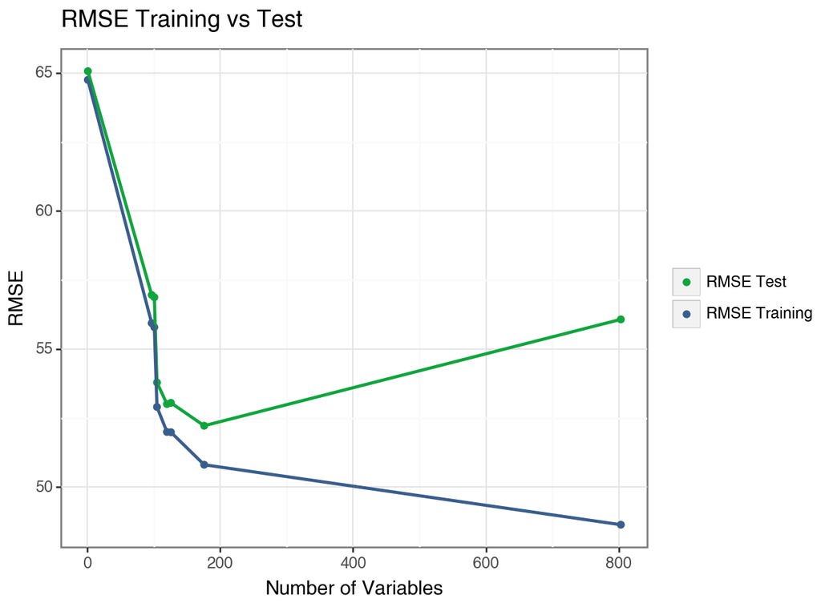

```
<Figure Size: (640 x 480)>
```

```python
(
    ggplot(rmse_levels, aes(x="nvars", y="value", color="var"))
    + geom_point()
    + geom_line(size=1, show_legend=False, na_rm=True)
    + scale_color_manual(name="", values=(color[1], color[0]))
    + scale_y_continuous(name="RMSE")
    + labs(title="RMSE Training vs Test", x="Number of Variables")
    + theme_bw()
    + theme(subplots_adjust={"wspace": 0.25},legend_title=element_blank())
)
```

Model 7 is best performer!

## Lasso

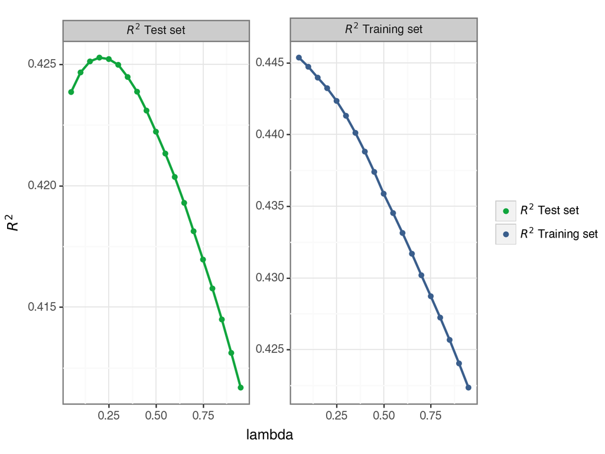

```
<Figure Size: (640 x 480)>
```

```python
(
    ggplot(r_squared_data, aes(x="lambda", y="value", color="variable"))
    + geom_point()
    + geom_line(size=1, show_legend=False, na_rm=True)
    + scale_color_manual(name="", values=(color[1], color[0]))
    + scale_y_continuous(name="$R^2$")
    + facet_wrap("variable", scales="free")
    + theme_bw()
    + theme(subplots_adjust={"wspace": 0.25},legend_title=element_blank())
)
```

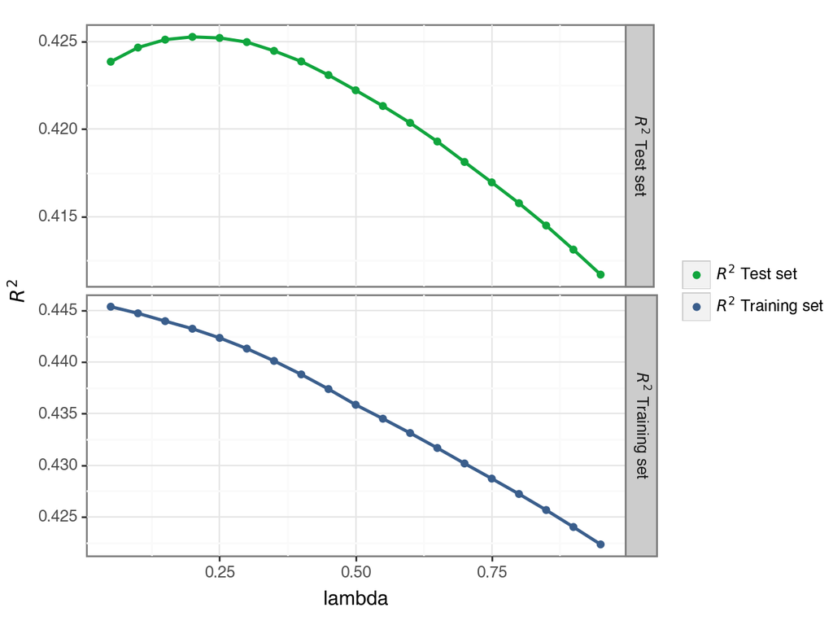

```
<Figure Size: (640 x 480)>
```

```python
(
    ggplot(r_squared_data, aes(x="lambda", y="value", color="variable"))
    + geom_point()
    + geom_line(size=1, show_legend=False, na_rm=True)
    + scale_color_manual(name="", values=(color[1], color[0]))
    + scale_y_continuous(name="$R^2$")
    + facet_grid("variable ~ .", scales="free")
    + theme_bw()
    + theme(subplots_adjust={"wspace": 0.25}, legend_title=element_blank())
)
```

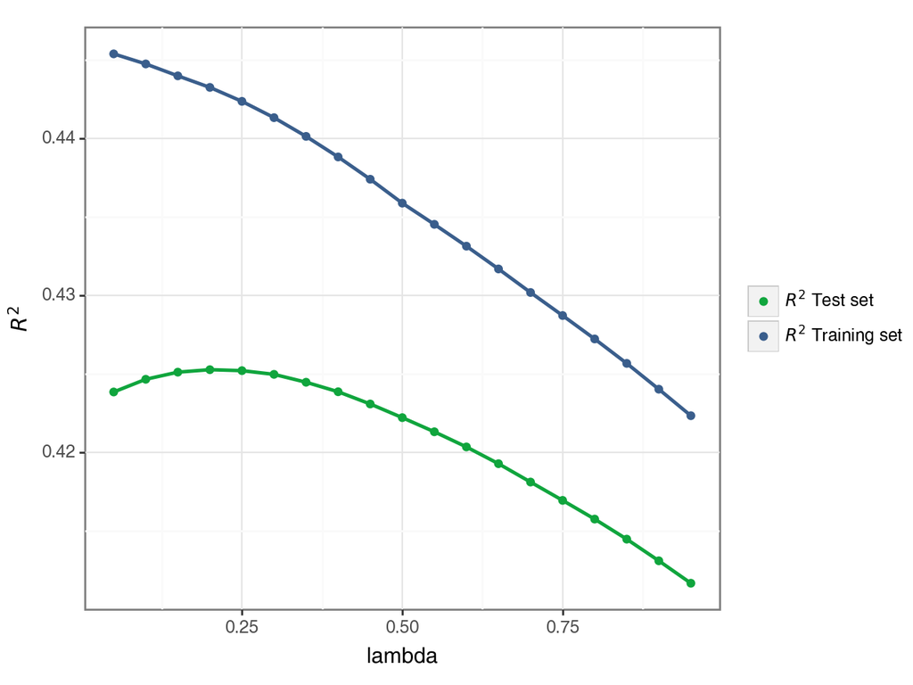

```
<Figure Size: (640 x 480)>
```

```python
(
    ggplot(r_squared_data, aes(x="lambda", y="value", color="variable"))
    + geom_point()
    + geom_line(size=1, show_legend=False, na_rm=True)
    + scale_color_manual(name="", values=(color[1], color[0]))
    + scale_y_continuous(name="$R^2$")
    + theme_bw()
    + theme(subplots_adjust={"wspace": 0.25}, legend_title=element_blank())
)
```

These graphs all show that the best performing lambda on the test set is around 0.2 but we can also check it with code

```python
df_lam = pd.DataFrame(test_r_squared*100, columns=['R_squared'])
df_lam['lambda'] = (lambdas)
# returns the index of the row where column has maximum value.
df_lam.loc[df_lam['R_squared'].idxmax()]
```

```
R_squared    42.527244
lambda        0.200000
Name: 3, dtype: float64
```

```python
reg_best = Lasso(alpha = df_lam.loc[df_lam['R_squared'].idxmax()]['lambda'])
reg_best.fit(X_train, y_train)
```

```
Lasso(alpha=0.2)
```

```python
np.sqrt(mean_squared_error(y_test, reg_best.predict(X_test)))
```

```
52.07810523621092
```

This is only slightly better than the OLS model.

## Lasso using gridsearch

```python
print("RMSE: " + str(results.best_score_ * -1))
```

```
RMSE: 51.69485389612446
```

```python
results.best_estimator_
```

```
Lasso(alpha=0.05)
```

```python
model7_level_holdout_predictions = pd.concat(
    [data_holdout["price"], model7_level.predict(data_holdout)],
    axis=1,
    keys=["price", "predicted"],
)
model7_level_holdout_predictions = model7_level_holdout_predictions[~model7_level_holdout_predictions.isna().any(axis=1)]
model7_level_holdout_rmse = rmse(model7_level_holdout_predictions["price"], model7_level_holdout_predictions["predicted"], axis=0)
print(
    f"RMSE work:{round(model7_level_work_rmse,2)}",
    "\t",
    f"RMSE holdout:{model7_level_holdout_rmse:.2f}",
    )
```

```
RMSE work:51.04 	 RMSE holdout:50.94
```

```python
model7_level.get_prediction(data_holdout).summary_frame(alpha=0.05)
```

|  | mean | mean_se | mean_ci_lower | mean_ci_upper | obs_ci_lower | obs_ci_upper |
| --- | --- | --- | --- | --- | --- | --- |
| 0 | 140.647133 | 4.400332 | 132.022641 | 149.271624 | 39.551844 | 241.742421 |
| 1 | 74.478803 | 4.828057 | 65.015986 | 83.941620 | -26.691452 | 175.649057 |
| 2 | 150.944260 | 5.279184 | 140.597249 | 161.291271 | 49.687477 | 252.201043 |
| 3 | 117.500500 | 3.601058 | 110.442556 | 124.558444 | 16.526790 | 218.474210 |
| 4 | 161.326335 | 5.350624 | 150.839305 | 171.813365 | 60.055147 | 262.597522 |
| ... | ... | ... | ... | ... | ... | ... |
| 3283 | 175.060580 | 7.461897 | 160.435531 | 189.685628 | 73.277636 | 276.843523 |
| 3284 | 115.911865 | 5.493196 | 105.145399 | 126.678332 | 14.611360 | 217.212370 |
| 3285 | 146.628561 | 4.870503 | 137.082550 | 156.174571 | 45.450491 | 247.806631 |
| 3286 | 144.393121 | 3.861313 | 136.825087 | 151.961154 | 43.382474 | 245.403767 |
| 3287 | 128.408468 | 6.372501 | 115.918595 | 140.898341 | 26.910328 | 229.906608 |

3288 rows × 6 columns

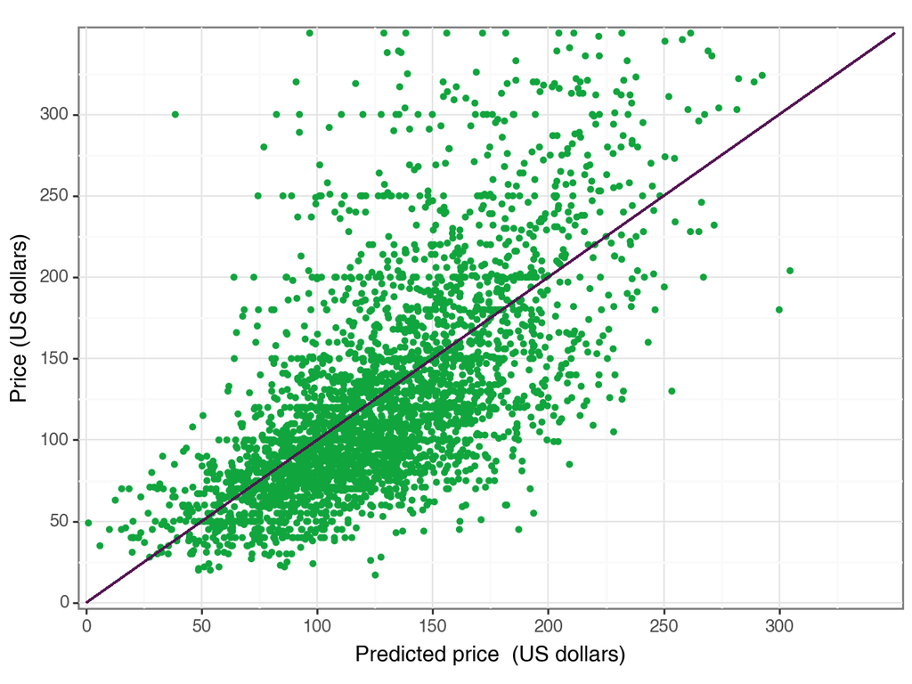

```
<Figure Size: (640 x 480)>
```

```python
(
    ggplot(data=data_diagnostic)
    + geom_point(
        aes(y="Ylev", x="mean"),
        color=color[1],
        size=1,
        alpha=0.7,
        show_legend=False,
        na_rm=True,
    )
    + geom_segment(aes(x=0, y=0, xend=350, yend=350), size=0.5, color=color[2])
    + coord_cartesian(xlim=(0, 350), ylim=(0, 350))
    + scale_x_continuous(
        expand=(0.01, 0.01), limits=(0, 350), breaks=seq(0, 350, by=50)
    )
    + scale_y_continuous(
        expand=(0.01, 0.01), limits=(0, 350), breaks=seq(0, 350, by=50)
    )
    + labs(y="Price (US dollars)", x="Predicted price  (US dollars)")
    + theme_bw()
)
```

## Random Forest, Gradient Boosting Method

For Random Forest we use the same variables as before except for the non-liner and interactions elements

```python
basic = [
    "f_room_type",
    "n_accommodates",
    "n_bedrooms",
    "n_beds",
    "flag_beds",
    "flag_bedrooms",
    "f_property_type",
    "f_neighbourhood_cleansed",
    "n_bathrooms",
    "n_minimum_nights",
]
host = ["d_host_is_superhost",
       "d_host_has_profile_pic",
       "d_host_identity_verified",
       "p_host_acceptance_rate"
]

availability = ["n_availability_30",
                "n_availability_60",
                "n_availability_90",
                "n_availability_365"]



reviews = ["n_number_of_reviews", "n_review_scores_rating", "flag_review_scores_rating",
           "n_number_of_reviews_ltm", "n_number_of_reviews_l30d", "n_review_scores_accuracy",
            "n_review_scores_cleanliness", "n_review_scores_checkin", "n_review_scores_communication",
            "n_review_scores_location", "n_review_scores_value", "n_reviews_per_month",
            "flag_review_scores_cleanliness", "flag_review_scores_checkin",
            "flag_review_scores_communication", "flag_review_scores_location", "flag_review_scores_value"
]

amenities = [col for col in data if col.startswith("da_")]
```

```python
predictors_1 = basic
predictors_2 = basic + host
predictors_3 = basic + host + availability
predictors_4 = basic + host + availability + reviews
predictors_5 = basic + host + availability + reviews + amenities
```

```python
import math
print('The theoretical recommended number of variables: {:.2f}.'.format(math.sqrt(len(X.design_info.column_names))))
```

```
The theoretical recommended number of variables: 13.30.
```

```python
tune_grid = {"max_features": [8, 10, 12, 14, 16], "min_samples_leaf": [5, 10, 15]}
```

```python
%%time
rf_model = rf_random.fit(X, y.ravel())
```

```
Fitting 5 folds for each of 15 candidates, totalling 75 fits
[CV 1/5] END max_features=8, min_samples_leaf=5;, score=-53.757 total time=   1.8s
[CV 2/5] END max_features=8, min_samples_leaf=5;, score=-51.553 total time=   1.6s
[CV 3/5] END max_features=8, min_samples_leaf=5;, score=-52.787 total time=   1.7s
[CV 4/5] END max_features=8, min_samples_leaf=5;, score=-53.518 total time=   1.6s
[CV 5/5] END max_features=8, min_samples_leaf=5;, score=-54.305 total time=   1.8s
[CV 1/5] END max_features=8, min_samples_leaf=10;, score=-54.688 total time=   1.2s
[CV 2/5] END max_features=8, min_samples_leaf=10;, score=-52.512 total time=   1.4s
[CV 3/5] END max_features=8, min_samples_leaf=10;, score=-53.769 total time=   1.2s
[CV 4/5] END max_features=8, min_samples_leaf=10;, score=-54.408 total time=   1.4s
[CV 5/5] END max_features=8, min_samples_leaf=10;, score=-55.269 total time=   1.2s
[CV 1/5] END max_features=8, min_samples_leaf=15;, score=-55.422 total time=   1.1s
[CV 2/5] END max_features=8, min_samples_leaf=15;, score=-53.364 total time=   1.1s
[CV 3/5] END max_features=8, min_samples_leaf=15;, score=-54.749 total time=   1.2s
[CV 4/5] END max_features=8, min_samples_leaf=15;, score=-54.991 total time=   1.1s
[CV 5/5] END max_features=8, min_samples_leaf=15;, score=-55.875 total time=   1.1s
[CV 1/5] END max_features=10, min_samples_leaf=5;, score=-53.186 total time=   2.2s
[CV 2/5] END max_features=10, min_samples_leaf=5;, score=-50.886 total time=   2.0s
[CV 3/5] END max_features=10, min_samples_leaf=5;, score=-52.206 total time=   1.9s
[CV 4/5] END max_features=10, min_samples_leaf=5;, score=-52.855 total time=   1.9s
[CV 5/5] END max_features=10, min_samples_leaf=5;, score=-53.432 total time=   2.0s
[CV 1/5] END max_features=10, min_samples_leaf=10;, score=-54.084 total time=   1.5s
[CV 2/5] END max_features=10, min_samples_leaf=10;, score=-51.837 total time=   1.4s
[CV 3/5] END max_features=10, min_samples_leaf=10;, score=-53.186 total time=   1.5s
[CV 4/5] END max_features=10, min_samples_leaf=10;, score=-53.892 total time=   1.5s
[CV 5/5] END max_features=10, min_samples_leaf=10;, score=-54.730 total time=   1.5s
[CV 1/5] END max_features=10, min_samples_leaf=15;, score=-54.641 total time=   1.2s
[CV 2/5] END max_features=10, min_samples_leaf=15;, score=-52.687 total time=   1.4s
[CV 3/5] END max_features=10, min_samples_leaf=15;, score=-53.889 total time=   1.2s
[CV 4/5] END max_features=10, min_samples_leaf=15;, score=-54.449 total time=   1.4s
[CV 5/5] END max_features=10, min_samples_leaf=15;, score=-55.184 total time=   1.4s
[CV 1/5] END max_features=12, min_samples_leaf=5;, score=-52.758 total time=   2.2s
[CV 2/5] END max_features=12, min_samples_leaf=5;, score=-50.519 total time=   2.2s
[CV 3/5] END max_features=12, min_samples_leaf=5;, score=-52.021 total time=   2.2s
[CV 4/5] END max_features=12, min_samples_leaf=5;, score=-52.572 total time=   2.3s
[CV 5/5] END max_features=12, min_samples_leaf=5;, score=-53.018 total time=   2.3s
[CV 1/5] END max_features=12, min_samples_leaf=10;, score=-53.692 total time=   2.2s
[CV 2/5] END max_features=12, min_samples_leaf=10;, score=-51.202 total time=   1.9s
[CV 3/5] END max_features=12, min_samples_leaf=10;, score=-52.979 total time=   2.0s
[CV 4/5] END max_features=12, min_samples_leaf=10;, score=-53.337 total time=   2.1s
```

[output cut: 23 more lines]

```
[CV 3/5] END max_features=16, min_samples_leaf=5;, score=-51.298 total time=   2.9s
[CV 4/5] END max_features=16, min_samples_leaf=5;, score=-52.002 total time=   2.9s
[CV 5/5] END max_features=16, min_samples_leaf=5;, score=-52.504 total time=   3.0s
[CV 1/5] END max_features=16, min_samples_leaf=10;, score=-53.063 total time=   2.5s
[CV 2/5] END max_features=16, min_samples_leaf=10;, score=-50.547 total time=   2.5s
[CV 3/5] END max_features=16, min_samples_leaf=10;, score=-52.014 total time=   2.2s
[CV 4/5] END max_features=16, min_samples_leaf=10;, score=-52.669 total time=   2.3s
[CV 5/5] END max_features=16, min_samples_leaf=10;, score=-53.470 total time=   2.4s
[CV 1/5] END max_features=16, min_samples_leaf=15;, score=-53.796 total time=   1.9s
[CV 2/5] END max_features=16, min_samples_leaf=15;, score=-51.146 total time=   1.9s
[CV 3/5] END max_features=16, min_samples_leaf=15;, score=-52.584 total time=   1.9s
[CV 4/5] END max_features=16, min_samples_leaf=15;, score=-53.330 total time=   1.9s
[CV 5/5] END max_features=16, min_samples_leaf=15;, score=-53.971 total time=   2.0s
CPU times: total: 1min 57s
Wall time: 2min 36s
```

```python
df_rf_model_cv_results = pd.DataFrame(rf_model.cv_results_)[[
    'param_max_features', 'param_min_samples_leaf', 'mean_test_score']]

df_rf_model_cv_results.columns = ['max features', 'min node size', 'RMSE']
df_rf_model_cv_results
```

|  | max features | min node size | RMSE |
| --- | --- | --- | --- |
| 0 | 8 | 5 | -53.183992 |
| 1 | 8 | 10 | -54.129266 |
| 2 | 8 | 15 | -54.880306 |
| 3 | 10 | 5 | -52.512934 |
| 4 | 10 | 10 | -53.546059 |
| 5 | 10 | 15 | -54.169968 |
| 6 | 12 | 5 | -52.177870 |
| 7 | 12 | 10 | -53.060118 |
| 8 | 12 | 15 | -53.647270 |
| 9 | 14 | 5 | -51.807895 |
| 10 | 14 | 10 | -52.677357 |
| 11 | 14 | 15 | -53.224505 |
| 12 | 16 | 5 | -51.591524 |
| 13 | 16 | 10 | -52.352577 |
| 14 | 16 | 15 | -52.965340 |

```python
df_rf_model_cv_results.pivot(
    index = 'max features',
    columns = 'min node size',
    values = 'RMSE').round(2)*-1
```

| min node size max features | 5 | 10 | 15 |
| --- | --- | --- | --- |
| 8 | 53.18 | 54.13 | 54.88 |
| 10 | 52.51 | 53.55 | 54.17 |
| 12 | 52.18 | 53.06 | 53.65 |
| 14 | 51.81 | 52.68 | 53.22 |
| 16 | 51.59 | 52.35 | 52.97 |

```python
rf_rmse = rf_model.best_score_ * -1
```

The RMSE is lowest for the most complex forest, which suggest that a we have not found the minimum point and a more complex forest might yield be able to yield better results. However this would also mean significantly larger use of resources and as the improvement only seems to be marginal we are satisfied with these result and try some other methodss to improve our model. Boosting. But first we look at feature importances, as these can contain very useful information.

```python
df_var_imp.style.format({
    'imp': lambda x: f'{x:,.1%}',
    'cumulative_imp': lambda x: f'{x:,.1%}'})
```

|  | variable | imp | cumulative_imp |
| --- | --- | --- | --- |
| 0 | f_neighbourhood_cleansed[T.DUOMO] | 5.8% | 5.8% |
| 1 | n_review_scores_location | 5.7% | 11.4% |
| 2 | n_bedrooms | 5.3% | 16.7% |
| 3 | n_availability_30 | 5.0% | 21.7% |
| 4 | n_availability_60 | 4.5% | 26.3% |
| 5 | n_accommodates | 4.3% | 30.6% |
| 6 | n_bathrooms | 4.3% | 34.9% |
| 7 | n_availability_90 | 4.3% | 39.2% |
| 8 | n_reviews_per_month | 3.2% | 42.4% |
| 9 | n_availability_365 | 3.2% | 45.6% |
| 10 | f_neighbourhood_cleansed[T.BRERA] | 2.9% | 48.5% |
| 11 | flag_bedrooms | 2.8% | 51.3% |
| 12 | n_number_of_reviews | 2.8% | 54.1% |
| 13 | n_number_of_reviews_ltm | 2.3% | 56.4% |
| 14 | f_room_type[T.Private] | 2.2% | 58.6% |
| 15 | p_host_acceptance_rate | 2.1% | 60.6% |
| 16 | n_review_scores_rating | 1.9% | 62.5% |
| 17 | n_review_scores_value | 1.8% | 64.4% |
| 18 | da_dishwasher | 1.8% | 66.1% |
| 19 | n_beds | 1.8% | 67.9% |
| 20 | n_review_scores_accuracy | 1.7% | 69.6% |
| 21 | n_review_scores_cleanliness | 1.7% | 71.3% |
| 22 | n_review_scores_checkin | 1.7% | 73.0% |
| 23 | n_minimum_nights | 1.7% | 74.7% |
| 24 | n_review_scores_communication | 1.6% | 76.3% |
| 25 | da_free_street_parking | 1.4% | 77.7% |
| 26 | f_property_type[T.Private room in rental unit] | 1.0% | 78.7% |
| 27 | n_number_of_reviews_l30d | 0.9% | 79.6% |
| 28 | da_hot_water_kettle | 0.6% | 80.2% |
| 29 | da_cooking_basics | 0.6% | 80.8% |

[output cut: 147 more lines]

[figure not shown]

```python
df_var_imp\
    .sort_values(by = 'imp')\
    .plot(kind = 'barh',
          x = 'variable', y = 'imp',
          figsize = (10,10), grid = True,
          title = 'Random forest model highest feature importances',
          xlabel = 'variables', legend = False
         );
plt.show()
```

Both of these are unusable mostly, lets limit and regroup the variables

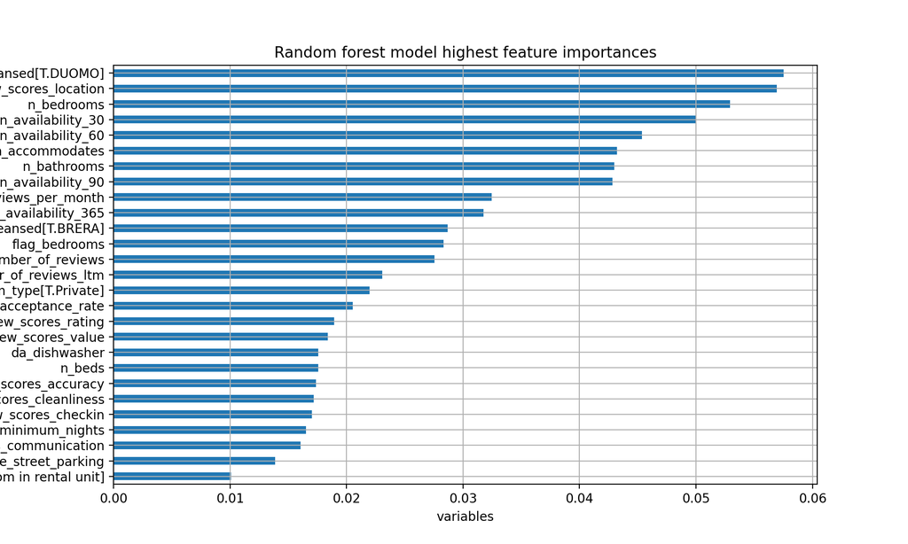

```python
df_var_imp[df_var_imp.imp > cutoff]\
    .sort_values(by = 'imp')\
    .plot(kind = 'barh',
          x = 'variable', y = 'imp',
          figsize = (10,6), grid = True,
          title = 'Random forest model highest feature importances',
          xlabel = 'variables', legend = False
         );

plt.show()
```

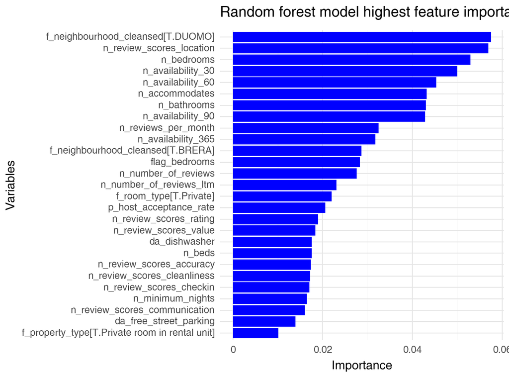

```python
# Create the ggplot object
df_var_imp_cutoff = df_var_imp[df_var_imp.imp > cutoff]

# Sort the DataFrame by 'imp' values in descending order
df_var_imp_cutoff_sorted = df_var_imp_cutoff.sort_values(by='imp', ascending=False)

df_var_imp_cutoff_sorted['variable'] = pd.Categorical(df_var_imp_cutoff_sorted['variable'],
                                                      categories=df_var_imp_cutoff_sorted['variable'],
                                                      ordered=True)

df_var_imp_cutoff_sorted['variable'] = df_var_imp_cutoff_sorted['variable'].cat.reorder_categories(
    df_var_imp_cutoff_sorted['variable'].cat.categories[::-1])

plot = (ggplot(df_var_imp_cutoff_sorted, aes(x='variable', y='imp'))
        + geom_bar(stat='identity', fill='blue')
        + theme_minimal()
        + ggtitle('Random forest model highest feature importances')
        + labs(x='Variables', y='Importance')
        + coord_flip()
       )

# Print the plot
print(plot)
```

```python
%%time
rf_pipeline.fit(data_train[predictors_5],data_train.price)
```

```
CPU times: total: 6.08 s
Wall time: 8.6 s
```

[output not shown]

```python
%%time
result = permutation_importance(
    rf_pipeline,
    data_holdout[predictors_5],
    data_holdout.price,
    n_repeats=10,
    random_state=45,
)
```

```
CPU times: total: 39.5 s
Wall time: 52.1 s
```

```python
pd.DataFrame(
        result.importances_mean,
        data_train[predictors_5].columns)
```

|  | 0 |
| --- | --- |
| f_room_type | 0.021852 |
| n_accommodates | 0.035845 |
| n_bedrooms | 0.040757 |
| n_beds | 0.004009 |
| flag_beds | 0.000009 |
| ... | ... |
| da_free_street_parking | 0.000000 |
| da_private_entrance | 0.000000 |
| da_private_patio_or_balcony | 0.000000 |
| da_luggage_dropoff_allowed | 0.000000 |
| da_smoke_alarm | 0.000000 |

85 rows × 1 columns

```python
df_grouped_var_imp.style.format({
    'imp': lambda x: f'{x:,.1%}',
    'cumulative_imp': lambda x: f'{x:,.1%}'})
```

|  | variable | imp | cumulative_imp |
| --- | --- | --- | --- |
| 0 | f_neighbourhood_cleansed | 19.8% | 19.8% |
| 1 | n_bathrooms | 4.3% | 24.2% |
| 2 | n_accommodates | 3.6% | 27.8% |
| 3 | f_room_type | 2.2% | 29.9% |
| 4 | f_property_type | 0.7% | 30.6% |
| 5 | n_beds | 0.4% | 31.0% |

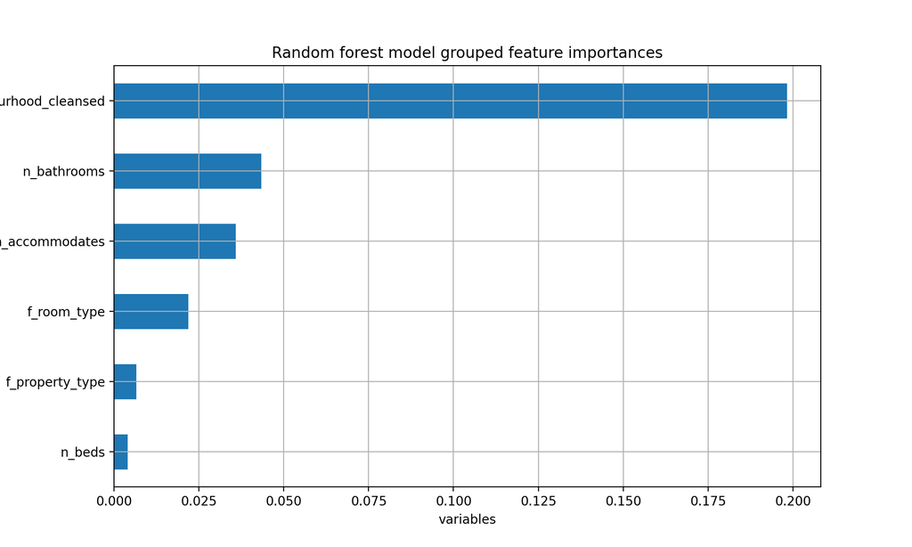

```python
df_grouped_var_imp\
    .sort_values(by = 'imp')\
    .plot(kind = 'barh',
          x = 'variable', y = 'imp',
          figsize = (10,6), grid = True,
          title = 'Random forest model grouped feature importances',
          xlabel = 'variables', legend = False
         );
plt.show()
```

```python
df_clean_varimp = pd.DataFrame(
        result.importances_mean,
        data_train[predictors_5].columns)\
    .sort_values(by = 0, ascending = False)\
    .reset_index()\
    .rename({'index': 'variable', 0: 'imp'}, axis = 1)

df_clean_varimp['cumulative_imp'] = df_var_imp['imp'].cumsum()
df_clean_varimp[df_clean_varimp.cumulative_imp < 0.91]
```

|  | variable | imp | cumulative_imp |
| --- | --- | --- | --- |
| 0 | f_neighbourhood_cleansed | 0.198294 | 0.057527 |
| 1 | n_bathrooms | 0.043399 | 0.114443 |
| 2 | n_bedrooms | 0.040757 | 0.167364 |
| 3 | n_accommodates | 0.035845 | 0.217410 |
| 4 | n_availability_30 | 0.030193 | 0.262753 |
| 5 | flag_bedrooms | 0.025076 | 0.305976 |
| 6 | n_availability_60 | 0.023286 | 0.348952 |
| 7 | p_host_acceptance_rate | 0.022918 | 0.391786 |
| 8 | f_room_type | 0.021852 | 0.424236 |
| 9 | n_availability_365 | 0.018587 | 0.456014 |
| 10 | n_minimum_nights | 0.017498 | 0.484695 |
| 11 | n_availability_90 | 0.015271 | 0.513028 |
| 12 | d_host_identity_verified | 0.009282 | 0.540572 |
| 13 | f_property_type | 0.006600 | 0.563648 |
| 14 | n_beds | 0.004009 | 0.585631 |
| 15 | d_host_is_superhost | 0.003201 | 0.606174 |
| 16 | flag_beds | 0.000009 | 0.625128 |
| 17 | d_host_has_profile_pic | 0.000006 | 0.643518 |
| 18 | da_first_aid_kit | 0.000000 | 0.661102 |
| 19 | da_coffee_maker | 0.000000 | 0.678674 |
| 20 | da_shower_gel | 0.000000 | 0.696061 |
| 21 | da_drying_rack_for_clothing | 0.000000 | 0.713263 |
| 22 | da_body_soap | 0.000000 | 0.730279 |
| 23 | da_oven | 0.000000 | 0.746814 |
| 24 | da_dishwasher | 0.000000 | 0.762888 |
| 25 | da_cleaning_products | 0.000000 | 0.776779 |
| 26 | da_extra_pillows_and_blankets | 0.000000 | 0.786870 |
| 27 | da_freezer | 0.000000 | 0.796036 |
| 28 | da_microwave | 0.000000 | 0.802010 |
| 29 | da_dining_table | 0.000000 | 0.807922 |
| 30 | da_dedicated_workspace | 0.000000 | 0.813563 |
| 31 | da_hot_water_kettle | 0.000000 | 0.819155 |
| 32 | da_host_greets_you | 0.000000 | 0.824429 |
| 33 | da_single_level_home | 0.000000 | 0.829611 |
| 34 | da_wine_glasses | 0.000000 | 0.834768 |
| 35 | da_pets_allowed | 0.000000 | 0.839831 |
| 36 | da_luggage_dropoff_allowed | 0.000000 | 0.844846 |
| 37 | da_private_patio_or_balcony | 0.000000 | 0.849448 |
| 38 | da_private_entrance | 0.000000 | 0.853968 |
| 39 | da_free_street_parking | 0.000000 | 0.858476 |
| 40 | da_free_washer__in_unit | 0.000000 | 0.862863 |
| 41 | da_fire_extinguisher | 0.000000 | 0.867235 |
| 42 | da_bidet | 0.000000 | 0.871503 |
| 43 | da_long_term_stays_allowed | 0.000000 | 0.875736 |
| 44 | da_baking_sheet | 0.000000 | 0.879941 |
| 45 | da_central_heating | 0.000000 | 0.884138 |
| 46 | da_self_checkin | 0.000000 | 0.888244 |
| 47 | da_roomdarkening_shades | 0.000000 | 0.892263 |
| 48 | da_coffee | 0.000000 | 0.896240 |
| 49 | da_stove | 0.000000 | 0.899885 |
| 50 | da_elevator | 0.000000 | 0.903486 |
| 51 | da_iron | 0.000000 | 0.907060 |

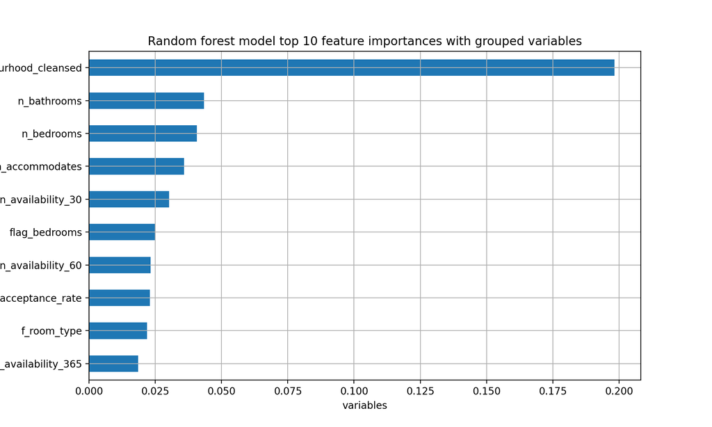

```python
df_clean_varimp.iloc[0:10]\
    .sort_values(by = 'imp')\
    .plot(kind = 'barh',
          x = 'variable', y = 'imp',
          figsize = (10,6), grid = True,
          title = 'Random forest model top 10 feature importances with grouped variables',
          xlabel = 'variables', legend = False
         );
plt.show()
```

```python
%%time
gbm_pipe.fit(data_train[predictors_5],data_train.price)
```

```
[Pipeline] ........ (step 1 of 2) Processing preprocess, total=   0.0s
Fitting 5 folds for each of 4 candidates, totalling 20 fits
[Pipeline] ......... (step 2 of 2) Processing regressor, total=  30.8s
CPU times: total: 3.41 s
Wall time: 30.9 s
```

```
Pipeline(steps=[('preprocess',
                 ColumnTransformer(transformers=[('cat',
                                                  OneHotEncoder(handle_unknown='ignore'),
                                                  ['f_room_type',
                                                   'f_property_type',
                                                   'f_neighbourhood_cleansed']),
                                                 ('num', 'passthrough',
                                                  ['n_accommodates',
                                                   'n_bedrooms', 'n_beds',
                                                   'flag_beds', 'flag_bedrooms',
                                                   'n_bathrooms',
                                                   'n_minimum_nights',
                                                   'd_host_is_superhost',
                                                   'd_host_has_profile_pic',
                                                   'd_host_ide...
                                                   'n_reviews_per_month',
                                                   'flag_review_scores_cleanliness',
                                                   'flag_review_scores_checkin',
                                                   'flag_review_scores_communication', ...])])),
                ('regressor',
                 GridSearchCV(cv=5,
                              estimator=GradientBoostingRegressor(max_features=10,
                                                                  min_samples_split=20),
                              n_jobs=-1,
                              param_grid={'max_depth': [5, 10],
                                          'n_estimators': [200, 300]},
                              scoring='neg_root_mean_squared_error',
                              verbose=10))],
         verbose=True)
```

```python
gbm_model_cv.cv_results_
```

```
{'mean_fit_time': array([ 7.24815125, 10.86064248, 10.68389883, 11.572861  ]),
 'std_fit_time': array([0.8747486 , 1.08634385, 0.59708095, 0.87584922]),
 'mean_score_time': array([0.13460321, 0.16631508, 0.14925594, 0.06694756]),
 'std_score_time': array([0.02660574, 0.00907326, 0.05178513, 0.01839357]),
 'param_max_depth': masked_array(data=[5, 5, 10, 10],
              mask=[False, False, False, False],
        fill_value='?',
             dtype=object),
 'param_n_estimators': masked_array(data=[200, 300, 200, 300],
              mask=[False, False, False, False],
        fill_value='?',
             dtype=object),
 'params': [{'max_depth': 5, 'n_estimators': 200},
  {'max_depth': 5, 'n_estimators': 300},
  {'max_depth': 10, 'n_estimators': 200},
  {'max_depth': 10, 'n_estimators': 300}],
 'split0_test_score': array([-49.86155206, -48.77911987, -49.62826818, -49.10522556]),
 'split1_test_score': array([-46.39814237, -45.95886701, -45.85537127, -45.70671766]),
 'split2_test_score': array([-48.41612505, -48.0743375 , -47.5887184 , -47.44510963]),
 'split3_test_score': array([-48.73722859, -48.2506994 , -48.08323154, -48.71705767]),
 'split4_test_score': array([-50.0754499 , -49.09989019, -48.55102193, -48.90740225]),
 'mean_test_score': array([-48.6976996 , -48.03258279, -47.94132226, -47.97630255]),
 'std_test_score': array([1.31313051, 1.09964341, 1.24202894, 1.27462257]),
 'rank_test_score': array([4, 3, 1, 2])}
```

```python
gbm_model_cv.best_estimator_
```

```
GradientBoostingRegressor(max_depth=10, max_features=10, min_samples_split=20,
                          n_estimators=200)
```

```python
gbm_rmse = gbm_model_cv.best_score_*-1
gbm_rmse
```

```
47.9413222643581
```

```python
results_df = pd.DataFrame({"Model":
                           ["Lasso OLS","OLS CV","Random Forest","Gradient Boosting Model"],
                            "RMSE":
                            [lasso_rmse,ols_rmse,rf_rmse,gbm_rmse]
                            })
comparing_results = results_df.sort_values(by="RMSE").reset_index(drop=True)
comparing_results
```

|  | Model | RMSE |
| --- | --- | --- |
| 0 | Gradient Boosting Model | 47.941322 |
| 1 | Lasso OLS | 50.941862 |
| 2 | Random Forest | 51.591524 |
| 3 | OLS CV | 52.223080 |

GBM has the best RMSE, it is the best performing model